# Practical_Machine_Learning_Prediction_Assign

DaanHoevers

Friday, February 20, 2015

### Introduction

This document is written for the course project of the Practical Machine Learning course, part of the Data Science Specialization by John Hopkins University on Coursera. In this project, data is used from accelerometers on the belt, forearm, arm, and dumbell of 6 participants. They were asked to perform barbell lifts correctly and incorrectly in 5 different ways. The goal of the project is to predict the manner in which they did the exercise, this is the “classe” variable.

### Data source

The data is obtain from the Groupware@LES which is a group of research and development of groupware technologies. The asked six young health participants to perform one set of 10 repetitions of the Unilateral Dumbbell Biceps Curl in five different fashions: exactly according to the specification (Class A), throwing the elbows to the front (Class B), lifting the dumbbell only halfway (Class C), lowering the dumbbell only halfway (Class D) and throwing the hips to the front (Class E).[Read More](http://groupware.les.inf.puc-rio.br/har#dataset)

### Exploratory Data Analyses

```r
training <- read.csv("pml-training.csv", header = TRUE, na.strings = c("", " ","NA"))
testing <- read.csv("pml-testing.csv", header = TRUE, na.strings = c("", " ","NA"))

a <- dim(training)
b <- dim(testing)
```

The training set given has 19622 rows with 160 observations, while the testing set has 20 rows with 160 observations. This means that of the total data set of 19642, 0.999 is in the Training set and 0.001 in the Testing set.

The distribution of class level outcomes in the training set is as follows:

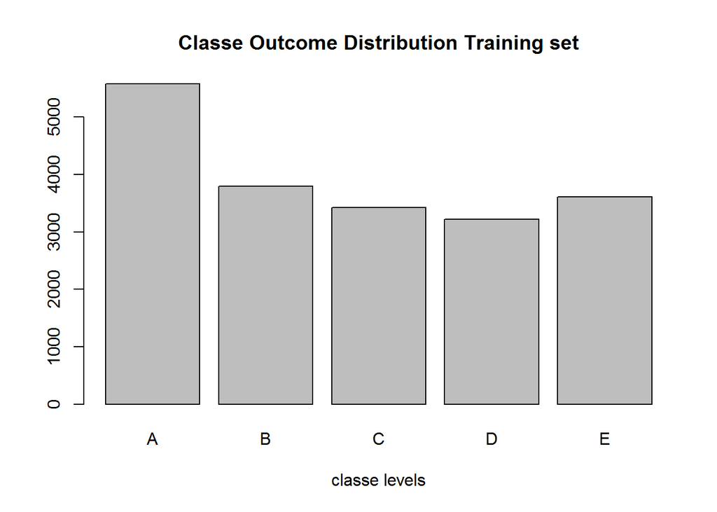

Of the 160 observation colums 100 have NA values included which are therefore not considered useful as predictor and are removed. Also, the first 7 columns contain information about the experiments not considered as an accelerometer predictor and those are also removed. The same is applied to the testing set.

```r
training <- training[, !x]
training <- training[,-c(1:7)]
dim(training)
```

```
## [1] 19622    53
```

```r
testing <- testing[, !x]
testing <- testing[,-c(1:7)]
```

### Split Training Data

To further split the Training data set, 80% of the Training set is allocated to the Train set and 20% to a Validation set.

```r
library(caret)
inTrain <- createDataPartition(y = training$classe, p = 0.8, list = FALSE)

Train <- training[inTrain,]
Validation <- training[-inTrain,]

dim(Train)
```

```
## [1] 15699    53
```

```r
dim(Validation)
```

```
## [1] 3923   53
```

### Build model using Train data set

To build the model, 3 methods are explored:

1. Predicting with trees, method is ‘rpart’
2. Random Forests, method is ‘rf’
3. Boosting with trees, method is ‘gbm’

In order to mitigate the risk of overfitting **5-fold cross validation** is used.

```r
fit_control <- trainControl(method = "cv", number = 5, allowParallel = TRUE, verboseIter = TRUE)

set.seed(985)## Predicting with Trees
modFit1 <- train(classe ~ ., data = Train, method = "rpart", trControl = fit_control)
set.seed(986) ## Random Forests
modFit2 <- train(classe ~ ., data = Train, method = "rf", trControl = fit_control)
set.seed(987) ## Boosting with Trees
modFit3 <- train(classe ~ ., data = Train, method = "gbm", verbose = FALSE, trControl = fit_control)
df <- rbind(modFit1$results$Accuracy,
            modFit2$results$Accuracy,
            head(sort(modFit3$results$Accuracy, decreasing = TRUE), 3))
rownames(df) <- c("Predicting with Trees", "Random Forests", "Boosting with trees")
round(df,4)
```

```
##                         [,1]   [,2]   [,3]
## Predicting with Trees 0.5167 0.4149 0.3321
## Random Forests        0.9928 0.9930 0.9891
## Boosting with trees   0.9599 0.9406 0.9304
```

Based on this overview of accuracies, the Random Forest Model shows the best results with a maximal accuracy of 0.993 Disadvantage of this method is that the processing time is longer.

```r
modFit2$finalModel ## modFit2 uses to Random Forest Model
```

```
##
## Call:
##  randomForest(x = x, y = y, mtry = param$mtry)
##                Type of random forest: classification
##                      Number of trees: 500
## No. of variables tried at each split: 27
##
##         OOB estimate of  error rate: 0.56%
## Confusion matrix:
##      A    B    C    D    E class.error
## A 4460    2    1    0    1   0.0008961
## B   18 3010    9    1    0   0.0092166
## C    0   14 2713   11    0   0.0091308
## D    0    1   17 2551    4   0.0085503
## E    0    1    2    6 2877   0.0031185
```

```r
varImp(modFit2, scale = FALSE)
```

```
## rf variable importance
##
##   only 20 most important variables shown (out of 52)
##
##                      Overall
## roll_belt               1617
## pitch_forearm            982
## yaw_belt                 929
## magnet_dumbbell_z        740
## magnet_dumbbell_y        731
## pitch_belt               716
## roll_forearm             624
## accel_dumbbell_y         383
## magnet_dumbbell_x        316
## roll_dumbbell            315
## accel_forearm_x          286
## magnet_belt_z            280
## total_accel_dumbbell     248
## accel_dumbbell_z         243
## magnet_forearm_z         236
## magnet_belt_y            225
## accel_belt_z             222
## yaw_arm                  212
## gyros_belt_z             209
## magnet_belt_x            184
```

The predictors roll_belt, pitch_forarm and yawbelt are the most important variables in the model. A pair scatter plot matrix shows the relation between them and effect on the class outcome, i.e. the colours.

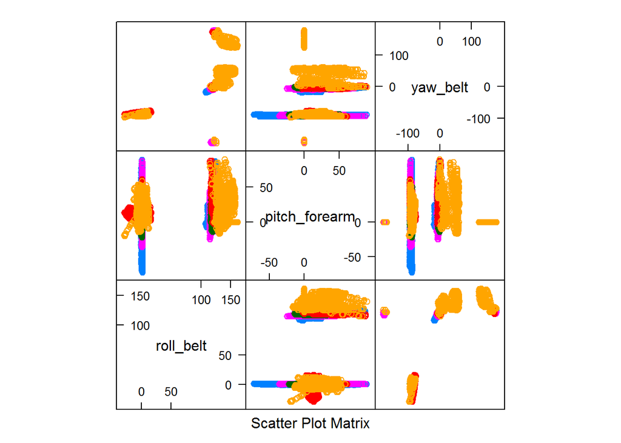

### Evaluate model on Validation data set

To determine the **out of sample error** the prediction model is applied to an new data set, the sub test set data.

```r
pred <- predict (modFit2, Validation)

conf_mat <- confusionMatrix(pred, Validation$classe)
conf_mat
```

```
## Confusion Matrix and Statistics
##
##           Reference
## Prediction    A    B    C    D    E
##          A 1114    2    0    0    0
##          B    2  757    3    0    0
##          C    0    0  680    5    2
##          D    0    0    1  638    0
##          E    0    0    0    0  719
##
## Overall Statistics
##
##                Accuracy : 0.996
##                  95% CI : (0.994, 0.998)
##     No Information Rate : 0.284
##     P-Value [Acc > NIR] : <2e-16
##
##                   Kappa : 0.995
##  Mcnemar's Test P-Value : NA
##
## Statistics by Class:
##
##                      Class: A Class: B Class: C Class: D Class: E
## Sensitivity             0.998    0.997    0.994    0.992    0.997
## Specificity             0.999    0.998    0.998    1.000    1.000
## Pos Pred Value          0.998    0.993    0.990    0.998    1.000
## Neg Pred Value          0.999    0.999    0.999    0.998    0.999
## Prevalence              0.284    0.193    0.174    0.164    0.184
## Detection Rate          0.284    0.193    0.173    0.163    0.183
## Detection Prevalence    0.284    0.194    0.175    0.163    0.183
## Balanced Accuracy       0.999    0.998    0.996    0.996    0.999
```

With an overall accuracy rate of 0.9962 and the 95% confidence interval with a lower limit of 0.9937 and an upper limit of 0.9979, the model is considered solid.

### Apply model on Testing data set

The model is now applied to the testing data set to obtain the answers which is submitted to the Coursera website.

```r
pred2 <- as.character(predict (modFit2, testing))

pml_write_files = function(x){
  n = length(x)
  for(i in 1:n){
    filename = paste0("problem_id_",i,".txt")
    write.table(x[i],file=filename,quote=FALSE,row.names=FALSE,col.names=FALSE)
  }
}

pml_write_files(pred2)

pred2
```

```
##  [1] "B" "A" "B" "A" "A" "E" "D" "B" "A" "A" "B" "C" "B" "A" "E" "E" "A"
## [18] "B" "B" "B"
```

All answers were submitted successfully to the Coursera website and all passed.